# 6. Conclusion & Outlook

# 6.1 Conclusion

Working with real-world data proves to be challenging, as always.

I was not able to draw conclusive results from the collected datasets that are significant enough to give any dependable statements. However, it was not all for nothing.

We saw in `notebook 4` that we can not derive any statistically meaningful relationship between time and the amount of burned area every year; Even when drawing in a lot more data. The wildfires in Sardinia are largely dominated by dispersed events, with some extreme ones burning over `1%` of the islands land mass within a few weeks. Fires can have their origin in many causes, ranging from natural sources like lightning and heat to intentional arson. Furthermore, it will take some time for sufficient fuel to regrow after a big fire event, such that it might by expectable to not see any kind of linear growth of burned area over time.

Still, `notebook 5` has shown that there is some degree of correlation between environmental factors and wildfires that point in the direction of our second hypothesis. That is: Wildfires are concurring with high heat and less water. Unfortunately the correlation is not significant enough to fully approve the thesis, but indicates a direction to further look into.

If my friends actually wanted to acquire property on the island, I would recommend them search for something in the south-east of Sardinia to the east of Cagliari. Although the northern part is equally calm in terms of fire activity (see **Figure 3.4** in `notebook 3`), it is much more crowded and expensive, as all the luxury travel is attracted by the Costa Smeralda. The mid-west is dominated by a big national park (Parco Nazionale del Golfo di Orosei e del Gennargentu) and will generally not be for sale.

The question is, where do we go from here if we want to get even more insights?

## 6.2 Outlook

At the start of this project I decided against the more granular pixel version of the Modis dataset, because it was involving a lot more data. However, I now assume that fires are starting in a rather small areas and then quickly spread. Thus, it would make a lot of sense to increase the spatial and temporal resolution of all data involved. The correlation between wind and fire might also become more apparent in smaller timescales.

Furthermore, it will also be much more efficient to work with the data in a more native format such as `geopandas`. Something I did not use for this project as I had to learn many things from the get go and wanted have full insight and control into what I was doing with the data.

I want to finish by throwing all the available data into an unsupervised dimensionality reduction model. T-Stochastic Neighbor Embedding minimizes the Kullback-Leibler distance of the joint probability between the high dimensional input data and a lower dimensional embedding. In this case the embedding dimension is 2. Size and color of the embedded data points are given by the magnitude of its labels, here being the `burned_area` for size and a second variable to visualize its influence (see **Figure 6.1**).

These kinds of unsupervised machine learning models are a great way to extend classical statistics and can help uncover relations in our datasets, which we did not think of before. The data seems to cluster in different regions and we can clearly identify the region of high wildfire activity.

```python
import pickle
import numpy as np
from sklearn.manifold import TSNE
import matplotlib.pyplot as plt

with open("../data/all_data_processed.pkl","rb") as datafile:
    data = pickle.load(datafile)

flattened = np.stack([data[var].reshape(-1) \
                      for var in ["cvh","cvl","tvh","tvl","tp","skt",
                                  "ssr","windspeed","swvl1","t2m"]]).transpose()

embedded = TSNE(n_components=2, learning_rate="auto", init="pca").fit_transform(flattened)
```

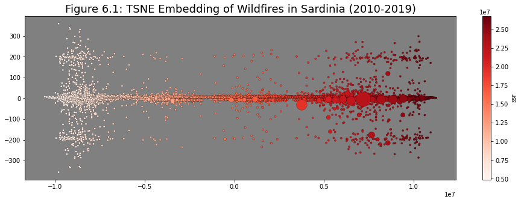

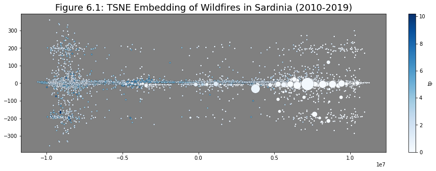

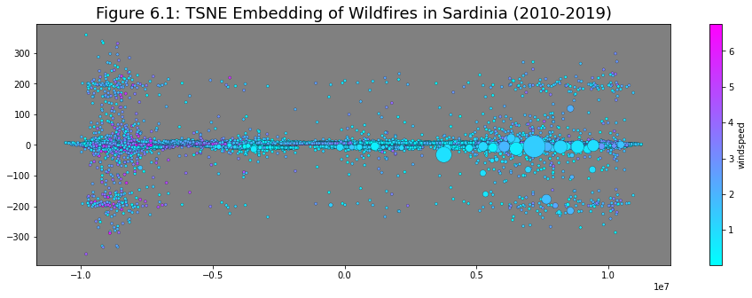

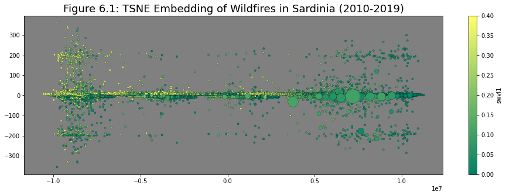

```python
label = data["burned_area"].reshape(-1)
order = np.argsort(label)

for color_var, cm in zip(["ssr","tp","windspeed","swvl1"], ["Reds","Blues","cool","summer"]):
    fig = plt.figure(figsize=(16,5))
    plt.scatter(embedded[order,0], embedded[order,1], c=data[color_var].reshape(-1)[order],
                s=10+6e2*label[order]/np.max(label), edgecolor="black", lw=0.2, cmap=cm)
    plt.colorbar(label=color_var)
    plt.gca().set_facecolor('grey')
    _ = plt.title("Figure 6.1: TSNE Embedding of Wildfires in Sardinia (2010-2019)", fontsize=18)
```